# Estudio sobre la depresión estudiantil. Grupo 5. Modelado y Caracterización de Perfiles

Miguel Encina Martinez, Daniel Galván Cancio, Jaime Linares Barrera, Daniel Vela Camacho

# Introducción

En este documento abordamos la **caracterización clínica** de los perfiles de riesgo en la población estudiantil.

Retomando las conclusiones de la fase previa, hemos establecido matemáticamente que la estructura subyacente del dataset maximiza su **cohesión** interna usando una partición de $k=3$ grupos. Este descubrimiento no es una asunción a priori, sino una conclusión validada mediante pruebas de estrés de silueta y análisis de estabilidad estructural.

## Preguntas y Objetivos

Nuestra estrategia de análisis busca resolver tres cuestiones fundamentales para la caracterización del riesgo:

- **Validación de perfiles**: ¿Se confirman los $k=3$ clusters como entidades clínicamente diferenciables (e.g., *Bajo*, *Medio*, *Alto*) al examinar sus medoides?
- **Identificación de discriminantes**: ¿Qué covariables específicas (académicas, financieras o sociales) presentan la mayor carga discriminante entre los perfiles extremos?
- **Robustez topológica**: ¿Mantiene la estructura de grupos su coherencia cuando se somete a métodos de aglomeración jerárquica con diferentes métricas de enlace (*linkage*)?

Procedemos a cargar el dataset optimizado resultante de la fase anterior. Este archivo contiene exclusivamente las variables seleccionadas por Información Mutua (MI), eliminando el ruido que dificultaba la convergencia en etapas previas.

```r
student_data_clustering_mi <- read.csv("data/student_depression_numeric_standard_mi.csv")
```

Validamos que las variables se encuentren en formato numérico y mantengan la estandarización necesaria (escalas comparables) para que el cálculo de distancias de CLARA no se vea sesgado por magnitudes dispares.

```r
head(student_data_clustering_mi)
```

```
##   Had.suicidal.thoughts Academic.Pressure Financial.Stress        Age
## 1             0.7619473         1.3453951        -1.488559  1.4636878
## 2            -1.3123795        -0.8265708        -0.792760 -0.3706759
## 3            -1.3123795        -0.1025822        -1.488559  1.0560514
## 4             0.7619473        -0.1025822         1.294638  0.4445969
## 5             0.7619473         0.6214064        -1.488559 -0.1668577
## 6            -1.3123795        -0.8265708        -1.488559  0.6484151
##   Work.Study.Hours Dietary.Habits Study.Satisfaction     Degree Sleep.Duration
## 1       -1.1226157      1.3748389        -0.69391252 -0.1371477     -0.3542413
## 2       -1.1226157      0.1199654         1.51119962 -0.1371477     -0.3542413
## 3        0.4963858      1.3748389         1.51119962 -0.1371477     -1.2418567
## 4       -0.8527821      0.1199654        -0.69391252 -0.1371477      0.5333740
## 5       -1.6622829      0.1199654         0.04112486  1.1909865     -0.3542413
## 6       -0.8527821      1.3748389         0.04112486  2.5191207     -1.2418567
##         CGPA Family.History.Mental.Illness Depression
## 1  0.8953448                    -0.9686312        Yes
## 2 -1.2008888                     1.0323475         No
## 3 -0.4293109                     1.0323475         No
## 4 -1.4125606                     1.0323475        Yes
## 5  0.3217826                    -0.9686312         No
## 6 -1.3374512                    -0.9686312         No
```

# K-Medoides (CLARA)

## Preparación de los datos

Para garantizar la integridad del análisis no supervisado y evitar cualquier sesgo de información, es necesario excluir la variable objetivo `Depression`. Nuestro objetivo es descubrir patrones basados únicamente en las características intrínsecas de los estudiantes, sin la influencia de la etiqueta diagnóstica conocida.

```r
student_data_model <- student_data_clustering_mi %>%
  select(-Depression)
```

## Entrenamiento del modelo

Procedemos a la ejecución del algoritmo CLARA (Clustering Large Applications). Basándonos en la validación matemática previa, fijamos el número de clusters en $k=3$. Para asegurar la estabilidad y representatividad de los medoides, utilizamos una configuración robusta con 50 muestras (`samples = 50`) y activamos la lógica PAM (`pamLike = TRUE`), lo que optimiza la selección de los centros comparado con el método estándar.

```r
set.seed(123)

clara_model <- clara(
  x = student_data_model,
  k = 3,
  metric = "euclidean",
  samples = 50,
  sampsize = 1000,
  pamLike = TRUE
)
```

## Visualización de resultados

Finalmente, graficamos los clusters resultantes en un espacio bidimensional utilizando PCA. Esta visualización nos permite evaluar de manera sencilla la separación geométrica y la densidad de los grupos identificados.

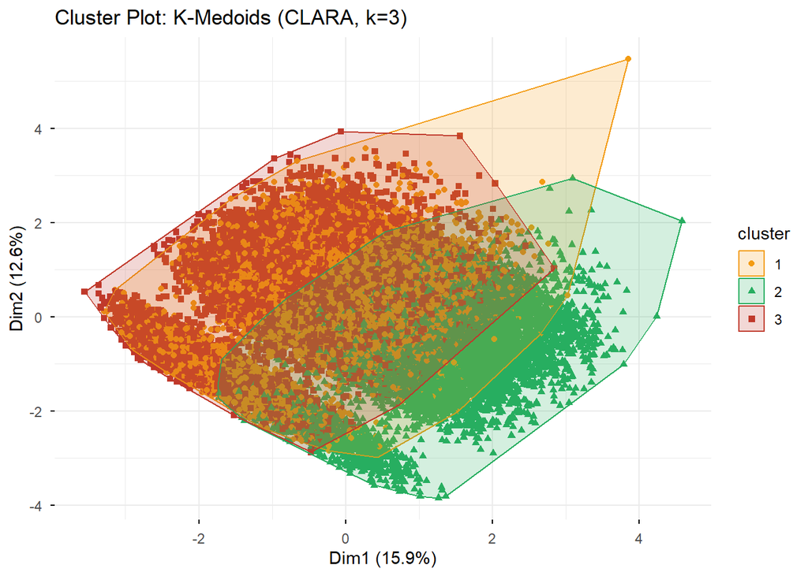

```r
fviz_cluster(clara_model,
             data = student_data_model,
             geom = "point",
             ellipse.type = "convex",
             ggtheme = theme_minimal(),
             main = "Cluster Plot: K-Medoids (CLARA, k=3)",
             palette = c("#F39C12", "#27AE60", "#C0392B"))
```

# Caracterización de Perfiles mediante Snake Plot

La visualización anterior (PCA en 2D) mostró solapamiento visual debido a la reducción de dimensionalidad, lo cual es esperado pero dificulta la interpretación clínica.

Para superar esta limitación visual, utilizaremos un **Snake Plot** (Gráfico de Coordenadas Paralelas). Esta técnica nos permite visualizar el valor promedio estandarizado (Z-Score) de cada variable para cada cluster, revelando la “firma clínica” de cada grupo.

## Transformación de Datos

En primer lugar, procedemos a asignar la etiqueta del cluster a cada observación y a reestructurar los datos. Calcularemos la media estandarizada de cada variable por cluster y transformaremos el dataset a un formato largo para facilitar su representación gráfica.

```r
data_perfilado <- student_data_model %>%
  mutate(Cluster = as.factor(clara_model$clustering))

data_long <- data_perfilado %>%
  group_by(Cluster) %>%
  summarise(across(everything(), mean)) %>%
  pivot_longer(cols = -Cluster,
               names_to = "Variable",
               values_to = "Valor_Medio_Estandarizado")
```

## Generación del Gráfico

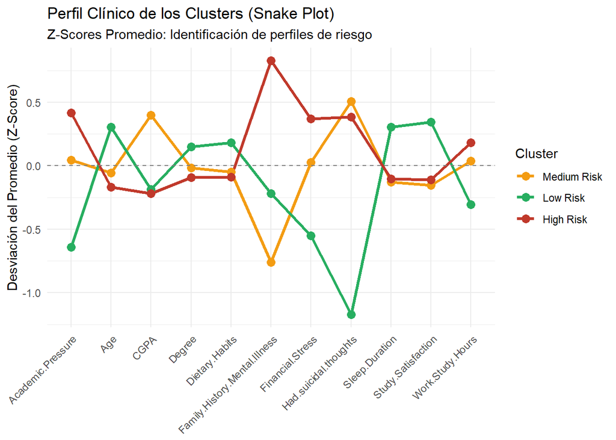

```r
ggplot(data_long, aes(x = Variable, y = Valor_Medio_Estandarizado,
                      group = Cluster, color = Cluster)) +
  geom_line(size = 1.2) +
  geom_point(size = 3) +
  geom_hline(yintercept = 0, linetype = "dashed", color = "gray50") +
  scale_color_manual(values = c("#F39C12", "#27AE60", "#C0392B"),
                     labels = c("Medium Risk", "Low Risk", "High Risk")) +
  labs(title = "Perfil Clínico de los Clusters (Snake Plot)",
       subtitle = "Z-Scores Promedio: Identificación de perfiles de riesgo",
       y = "Desviación del Promedio (Z-Score)",
       x = NULL) +
  theme_minimal() +
  theme(axis.text.x = element_text(angle = 45, hjust = 1))
```

## Análisis e interpretación de perfiles

# Validación externa

Una vez hemos detectado **quién** está en riesgo, el siguiente paso crítico es validar si nuestra “brújula matemática” apunta en la dirección correcta.

Hemos clasificado a los estudiantes en 3 perfiles de riesgo (Bajo, Medio, Alto) usando K-Medoids sin que el algoritmo conociera su estado real de salud. Ahora, procedemos a **“quitar la venda”** al modelo. Recuperaremos la variable `Depression` (que eliminamos temporalmente para el entrenamiento) y cruzaremos estos datos para verificar si nuestros clusters matemáticos coinciden con la realidad clínica.

```r
validation_df <- data_perfilado %>%
  mutate(Real_Depression = student_data_clustering_mi$Depression) %>%
  mutate(Real_Depression_Label = ifelse(Real_Depression == "Yes", "Depressed", "Not Depressed")) %>%
  mutate(Risk_Profile = case_when(
    Cluster == 3 ~ "High Risk",
    Cluster == 2 ~ "Low Risk",
    Cluster == 1 ~ "Medium Risk"
  )) %>%
  mutate(Risk_Profile = factor(Risk_Profile, levels = c("Low Risk", "Medium Risk", "High Risk")))

contingency_table <- validation_df %>%
  group_by(Risk_Profile, Real_Depression_Label) %>%
  summarise(Count = n(), .groups = 'drop') %>%
  group_by(Risk_Profile) %>%
  mutate(Percentage = round(Count / sum(Count) * 100, 1))

print(contingency_table)
```

```
## # A tibble: 6 × 4
## # Groups:   Risk_Profile [3]
##   Risk_Profile Real_Depression_Label Count Percentage
##   <fct>        <chr>                 <int>      <dbl>
## 1 Low Risk     Depressed               963       12.6
## 2 Low Risk     Not Depressed          6660       87.4
## 3 Medium Risk  Depressed              6684       70.5
## 4 Medium Risk  Not Depressed          2792       29.5
## 5 High Risk    Depressed              8618       80.6
## 6 High Risk    Not Depressed          2076       19.4
```

## Distribución de la depresión en los perfiles

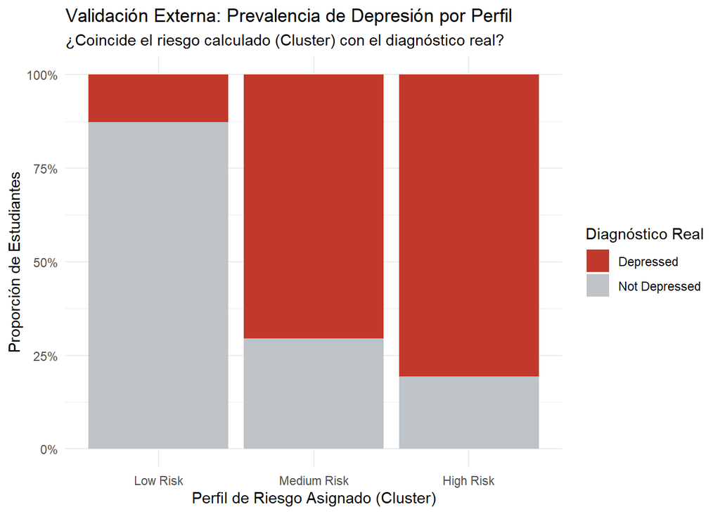

```r
ggplot(validation_df, aes(x = Risk_Profile, fill = Real_Depression_Label)) +
  geom_bar(position = "fill") +
  scale_y_continuous(labels = scales::percent) +
  scale_fill_manual(values = c("Depressed" = "#C0392B", "Not Depressed" = "#BDC3C7")) +
  labs(title = "Validación Externa: Prevalencia de Depresión por Perfil",
       subtitle = "¿Coincide el riesgo calculado (Cluster) con el diagnóstico real?",
       x = "Perfil de Riesgo Asignado (Cluster)",
       y = "Proporción de Estudiantes",
       fill = "Diagnóstico Real") +
  theme_minimal()
```

## Interpretación de los resultados

La confrontación de los clusters con los diagnósticos reales (`Real_Depression_Label`) valida la capacidad predictiva del modelo y revela una estructura de riesgo polarizada:

1. **Alta Discriminación del Perfil Sano:** El modelo demuestra una excelente especificidad al aislar el perfil **“Low Risk”**, donde la prevalencia de depresión es mínima (**12.6%**). Esto valida su utilidad como herramienta para descartar dichos casos con seguridad.
2. **No Linealidad del Riesgo:** Se observa un salto drástico, no gradual, en la patología. El grupo **“Medium Risk”** presenta una prevalencia del **70.5%**, una cifra alarmantemente cercana al **80.6%** del **“High Risk”**.

> El perfil “Medio” no representa una patología leve, sino un **estado crítico latente**. Los datos sugieren que, una vez superados ciertos umbrales de estrés (académico o financiero), la probabilidad de depresión se dispara.

# Reglas de Asociación

Sabiendo **quiénes** son los estudiantes en riesgo y habiendo validado la gravedad de su situación, ahora buscamos la **causa raíz** del problema.

¿Qué combinaciones específicas de factores detonan esta depresión? Para responder a esto, utilizamos técnicas de **Reglas de Asociación** con el algoritmo **Apriori**. El objetivo no es predecir un valor numérico, sino identificar combinaciones de factores (por ejemplo: *dieta + sueño + presión académica*) que actúan como “cócteles peligrosos” para la salud mental.

Cargamos el dataset original asegurando que las cadenas de texto se interpreten como factores, lo cual facilita el análisis categórico posterior.

```r
data_raw <- read.csv("data/student_depression_factors.csv", stringsAsFactors = TRUE)
```

Antes de aplicar el algoritmo, es fundamental revisar la naturaleza de las variables. El algoritmo Apriori requiere variables categóricas (factores), por lo que debemos identificar qué columnas son numéricas (y necesitarán discretización) y cuáles tienen una cardinalidad excesiva que podría introducir ruido.

```r
str(data_raw)
```

```
## 'data.frame':    27793 obs. of  14 variables:
##  $ Gender                       : Factor w/ 2 levels "Female","Male": 2 1 2 1 1 2 2 1 2 2 ...
##  $ Age                          : int  33 24 31 28 25 29 30 30 28 31 ...
##  $ City                         : Factor w/ 22 levels "Agra","Ahmedabad",..: 22 3 18 14 8 16 20 5 14 14 ...
##  $ Academic.Pressure            : int  5 2 3 3 4 2 3 2 3 2 ...
##  $ CGPA                         : num  8.97 5.9 7.03 5.59 8.13 5.7 9.54 8.04 9.79 8.38 ...
##  $ Study.Satisfaction           : int  2 5 5 2 3 3 4 4 1 3 ...
##  $ Sleep.Duration               : Factor w/ 4 levels "5-6 hours","7-8 hours",..: 1 1 3 2 1 3 2 3 2 3 ...
##  $ Dietary.Habits               : Factor w/ 3 levels "Healthy","Moderate",..: 1 2 1 2 2 1 1 3 2 2 ...
##  $ Degree                       : Factor w/ 4 levels "Bachillerato",..: 3 3 3 3 4 2 3 1 3 3 ...
##  $ Had.suicidal.thoughts        : int  1 0 0 1 1 0 0 0 1 1 ...
##  $ Work.Study.Hours             : int  3 3 9 4 1 4 1 0 12 2 ...
##  $ Financial.Stress             : int  1 2 1 5 1 1 2 1 3 5 ...
##  $ Family.History.Mental.Illness: int  0 1 1 1 0 0 0 1 0 0 ...
##  $ Depression                   : Factor w/ 2 levels "No","Yes": 2 1 1 2 1 1 1 1 2 2 ...
```

```r
summary(data_raw[, c("Age", "CGPA", "Work.Study.Hours","City")])
```

```
##       Age             CGPA        Work.Study.Hours          City
##  Min.   :18.00   Min.   : 5.030   Min.   : 0.00    Other      : 5733
##  1st Qu.:21.00   1st Qu.: 6.290   1st Qu.: 4.00    Kalyan     : 1562
##  Median :25.00   Median : 7.770   Median : 8.00    Srinagar   : 1367
##  Mean   :25.82   Mean   : 7.659   Mean   : 7.16    Hyderabad  : 1336
##  3rd Qu.:30.00   3rd Qu.: 8.920   3rd Qu.:10.00    Vasai-Virar: 1286
##  Max.   :59.00   Max.   :10.000   Max.   :12.00    Lucknow    : 1152
##                                                    (Other)    :15357
```

Basándonos en la inspección anterior, procedemos a descartar la variable `City`. Su alta cardinalidad fragmentaría el análisis generando reglas geográficas demasiado específicas y poco representativas del comportamiento general. Mantenemos el resto de variables demográficas, académicas y de hábitos para buscar patrones transversales.

```r
data_selected <- data_raw %>%
  select(-City)
```

Para que el algoritmo Apriori funcione, debemos transformar las variables numéricas continuas en rangos categóricos. Definimos los cortes basándonos en criterios académicos y biológicos: la edad se agrupa por etapas universitarias, el CGPA (rendimiento) en niveles de desempeño, y las horas de trabajo/estudio en carga laboral.

```r
data_discretized <- data_selected %>%
  mutate(
    Age_Group = cut(Age,
                    breaks = c(-Inf, 18, 22, Inf),
                    labels = c("Minor", "Undergrad", "Senior")),

    CGPA_Level = cut(CGPA,
                     breaks = c(-Inf, 6.5, 8.5, Inf),
                     labels = c("Low", "Medium", "High")),

    Work_Load = cut(Work.Study.Hours,
                    breaks = c(-Inf, 2, 6, Inf),
                    labels = c("Low", "Medium", "High"))
  ) %>%
  select(-Age, -CGPA, -Work.Study.Hours)
```

Las variables restantes contienen códigos numéricos (escalas 1-5 o binarios 0/1) que no son interpretables directamente por el algoritmo. Convertimos estas escalas en factores con etiquetas semánticas claras (ej. de “5” a “Critical”) y estandarizamos el resto de variables cualitativas para asegurar que todas sean tratadas como factores.

```r
data_transformed <- data_discretized %>%
  mutate(
    Academic_Pressure = factor(Academic.Pressure, levels = 0:5,
                               labels = c("None", "Min", "Low", "Moderate", "High", "Very High")),

    Study_Satisfaction = factor(Study.Satisfaction, levels = 0:5,
                                labels = c("None", "Min", "Low", "Moderate", "High", "Very High")),

    Financial_Stress = factor(Financial.Stress, levels = 1:5,
                              labels = c("Min", "Low", "Moderate", "High", "Critical")),

    Suicidal_Thoughts = factor(Had.suicidal.thoughts, levels = c(0, 1),
                               labels = c("No", "Yes")),

    Family_History = factor(Family.History.Mental.Illness, levels = c(0, 1),
                            labels = c("No", "Yes")),

    Sleep_Duration = as.factor(Sleep.Duration),
    Dietary_Habits = as.factor(Dietary.Habits),
    Degree = as.factor(Degree),
    Gender = as.factor(Gender),
    Depression = as.factor(Depression)
  ) %>%
  select(Academic_Pressure, Study_Satisfaction, Financial_Stress,
         Suicidal_Thoughts, Family_History, Sleep_Duration,
         Dietary_Habits, Degree, Gender, Depression,
         Age_Group, CGPA_Level, Work_Load)
```

El algoritmo Apriori no trabaja con dataframes convencionales, sino con una matriz dispersa de transacciones. Convertimos nuestros datos transformados a este formato, donde cada fila representa a un estudiante como un conjunto de “items” (sus características).

```r
data_transactions <- as(data_transformed, "transactions")
```

Ejecutamos el algoritmo buscando específicamente las reglas que tienen como consecuente la depresión (`Depression=Yes`). Configuramos un soporte mínimo del 5% para capturar patrones relevantes pero no necesariamente masivos, y una confianza del 50% para asegurar que la asociación sea significativa.

```r
rules <- apriori(data_transactions,
                 parameter = list(supp = 0.05, conf = 0.5),
                 appearance = list(default = "lhs", rhs = "Depression=Yes"),
                 control = list(verbose = FALSE))
```

Es común que el algoritmo genere reglas redundantes (versiones más complejas de una regla simple que no aportan más información). Filtramos estas redundancias matemáticamente y ordenamos las reglas restantes por **Lift**, que es la métrica clave para determinar cuánto aumenta el riesgo de depresión dada la presencia de los antecedentes.

```r
rules_pruned <- rules[!is.redundant(rules)]
rules_sorted <- sort(rules_pruned, by = "lift")
```

Una vez filtradas las reglas redundantes, examinamos las 10 mejores asociaciones ordenadas por *Lift*. Un valor de Lift superior a 1 indica una relación positiva; cuanto mayor sea este valor, más fuerte es la dependencia entre los antecedentes (LHS) y la depresión (RHS). Esto nos permite identificar los perfiles de riesgo más críticos.

```r
rules_df_final <- as(head(rules_sorted, 10), "data.frame")

rules_df_final <- rules_df_final[, c("rules", "support", "confidence", "lift", "count")]

rules_df_final$rules <- gsub("[\\{\\}]", "", rules_df_final$rules)
rules_df_final$rules <- gsub("=>", "→", rules_df_final$rules)
rules_df_final$rules <- gsub("Depression=Yes", "Depression", rules_df_final$rules)

rules_df_final$rules <- str_squish(rules_df_final$rules)

colnames(rules_df_final) <- c("Regla (Causa → Efecto)", "Soporte", "Confianza", "Lift", "Conteo")

rules_df_final$Lift <- cell_spec(sprintf("%.3f", rules_df_final$Lift),
                                 color = ifelse(rules_df_final$Lift > 1.65, "#C0392B", "black"),
                                 bold = ifelse(rules_df_final$Lift > 1.65, TRUE, FALSE))

kbl(rules_df_final,
    caption = "Top 10 Patrones de Riesgo Identificados",
    digits = 3,
    escape = FALSE,
    row.names = FALSE,
    align = "lcccc") %>%
  kable_styling(bootstrap_options = c("striped", "hover", "condensed"),
                full_width = TRUE,
                position = "center",
                font_size = 13) %>%
  row_spec(0, bold = TRUE, color = "white", background = "#4CAF50") %>%
  column_spec(1, bold = TRUE, width = "50em") %>%
  add_footnote("Lift > 1 indica una asociación positiva fuerte (mayor riesgo).", notation = "none")
```

Top 10 Patrones de Riesgo Identificados

| Regla (Causa → Efecto) | Soporte | Confianza | Lift | Conteo |
| --- | --- | --- | --- | --- |
| Academic_Pressure=Very High,Financial_Stress=Critical,Suicidal_Thoughts=Yes → Depression | 0.056 | 0.984 | 1.681 | 1553 |
| Academic_Pressure=Very High,Suicidal_Thoughts=Yes,Dietary_Habits=Unhealthy,Work_Load=High → Depression | 0.050 | 0.974 | 1.665 | 1403 |
| Academic_Pressure=Very High,Suicidal_Thoughts=Yes,Dietary_Habits=Unhealthy → Depression | 0.073 | 0.968 | 1.655 | 2020 |
| Academic_Pressure=Very High,Suicidal_Thoughts=Yes,Family_History=Yes,Work_Load=High → Depression | 0.057 | 0.968 | 1.654 | 1589 |
| Financial_Stress=Critical,Suicidal_Thoughts=Yes,Dietary_Habits=Unhealthy,Work_Load=High → Depression | 0.053 | 0.963 | 1.645 | 1478 |
| Academic_Pressure=Very High,Suicidal_Thoughts=Yes,Gender=Male,Work_Load=High → Depression | 0.060 | 0.959 | 1.639 | 1677 |
| Academic_Pressure=Very High,Suicidal_Thoughts=Yes,Work_Load=High → Depression | 0.112 | 0.959 | 1.639 | 3115 |
| Academic_Pressure=Very High,Suicidal_Thoughts=Yes,Sleep_Duration=Less than 5 hours → Depression | 0.057 | 0.959 | 1.639 | 1580 |
| Academic_Pressure=Very High,Financial_Stress=Critical → Depression | 0.066 | 0.954 | 1.630 | 1825 |
| Academic_Pressure=Very High,Suicidal_Thoughts=Yes,Family_History=Yes → Depression | 0.083 | 0.952 | 1.626 | 2316 |

Lift > 1 indica una asociación positiva fuerte (mayor riesgo).

## Interpretación Clínica de los Patrones

> Las intervenciones no deben enfocarse únicamente en “charla psicológica”. Se requiere un **enfoque estructural** que mitigue la **Presión Académica** y ofrezca redes de seguridad para el **Estrés Financiero**, ya que estos son los detonantes primarios que, una vez activados, se ven agravados por malos hábitos de salud.